# Hate in Context

Week 4: (Social) Media and Hate Crime · LENS preview

Violeta Haas

Department of Political Science

School of Social Sciences and Philosophy

Trinity College Dublin

# This Week

1. Catch-up — Week 3 policy pitch
2. Week 04 – Siegel (2020)
3. Offline consequences — Müller & Schwarz (2023)
4. Combating online hate speech
5. Outlook

# Catch-up — Week 3 policy pitch

## Policy advice (10-15min)

**Scenario.** The government has funding for precautionary measures to avoid spikes in hate crime. They have become aware of research linking economic conditions to bias-motivated crime and they are worried about **AI-driven job replacement**.

You are one of three advocacy organisations competing for the contract:

- Institute for Intergroup Safety (IIS)
- Alliance Against Bias Crime (AABC)
- Coalition for Hate Crime Prevention (CHCP)

**Your task** (3 Groups)

1. Design a short policy brief: what to worry about, what to fund, and why it should work. Draw on our readings.
2. Each group decide on one representative to pitch your brief (**2 minutes**).
3. Vote on who gets the job!

**A policy brief usually has…**

1. Title
2. Executive summary / recommendation
3. Problem / context
4. Evidence
5. Options
6. Preferred option
7. Implementation
8. Risks & caveats
9. Next steps

## Collect notes (5 min)

**If you were here last week**

Groups: **IIS**, **AABC**, **CHCP**

1. Collect your notes from the policy brief.
2. Decide who will pitch (**2 minutes**).

**If you missed last week**

While others prep, work on **Siegel (2020)** — *Online hate speech*:

1. What do we know about the **producers** of hate speech?
2. What do we know about the **targets** of hate speech?
3. How **prevalent** is hate speech?

Institute for Intergroup Safety  
(IIS)

Alliance Against Bias Crime  
(AABC)

Coalition for Hate Crime Prevention  
(CHCP)

## Who gets the job?

- Institute for Intergroup Safety (IIS)
- Alliance Against Bias Crime (AABC)
- Coalition for Hate Crime Prevention (CHCP)

on Blackboard → Week 03 → POU44653 Week 3: Who gets the job?

# Week 04 – Siegel (2020)

## Defining Hate Speech

Siegel (2020): there is **no single agreed definition**, definitions range from **maximal** to **minimal**.

### Maximal (broad)

[discussed in class]

### Minimal (narrow)

[discussed in class]

[discussed in class]

## Typical producers & targets

### Typical producers

[discussed in class]

### Typical targets

[discussed in class]

## Prevalence of online hate speech

### On platforms (content)

[discussed in class]

### In surveys (exposure)

[discussed in class]

[discussed in class]

# Offline consequences

## Müller & Schwarz (2023)

[figure not shown]

Question: Can social media amplify antiminority sentiment?

## Additional data sources

### Hate groups (SPLC)

- Annual census of active US hate and antigovernment groups (Hate Map)
- Tracks *organizations*, not individuals
- Based on publications, reports, field sources, and investigations

### Victimization (NCVS)

- Bureau of Justice Statistics’ main national survey of criminal victimization
- ~240,000 people in ~150,000 households each year
- Covers crimes reported *and* not reported to police

### Global Terrorism Database

- START (University of Maryland) open-source event database
- 200,000+ domestic and international terrorist attacks since 1970
- Date, location, weapons, targets, casualties, perpetrators

### ADL hate/incident data

- Tracks bias incidents of harassment, vandalism, and assault
- Includes criminal *and* non-criminal incidents
- Drawn from victims, law enforcement, media, and partner reports

## Motivation: hate crime trends

Figure 3

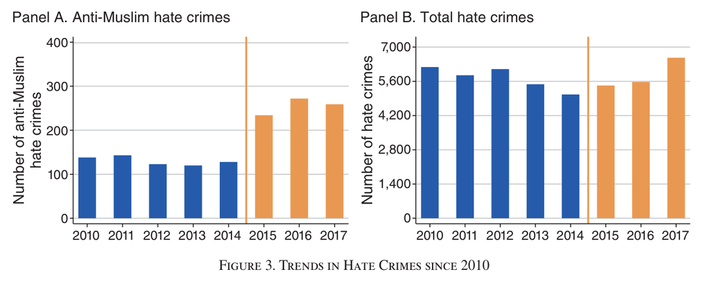

Anti-Muslim hate crimes rise sharply with the Trump campaign period. Total hate crimes less so until later.

## Findings: Twitter and hate crimes

**Did higher county Twitter use raise anti-Muslim hate crimes after Trump’s rise?**

Figure 4

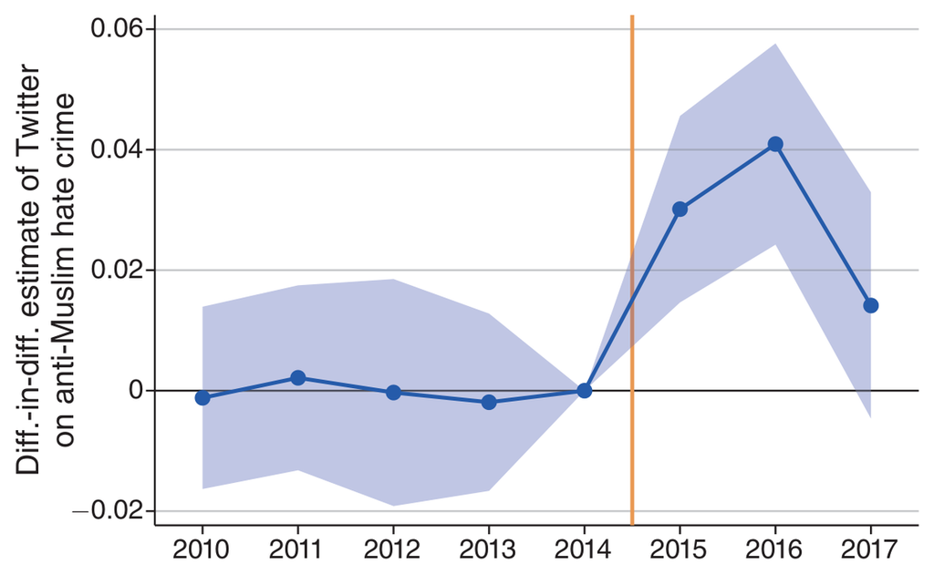

Figure 6

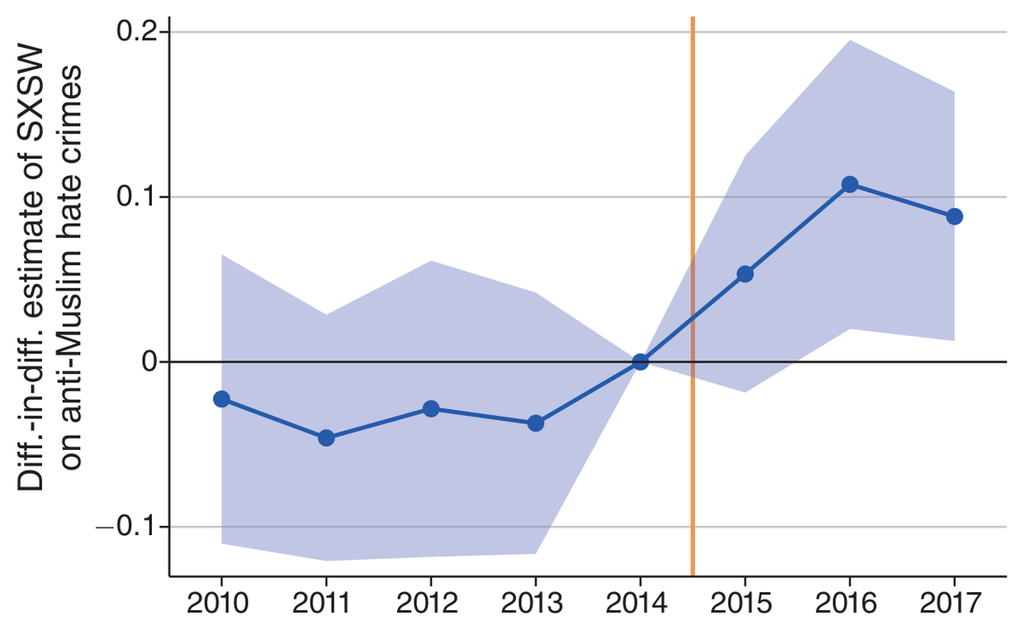

Same pattern for raw Twitter use (Fig. 4) and the SXSW instrument (Fig. 6): rise after 2015, flat before.

**SXSW as instrument**

South by Southwest is an annual festival/conference in Austin. The March 2007 event was a tipping point for Twitter’s early US growth.

**How they use it:** Counties of people who started following SXSW on Twitter around the 2007 festival predict later county Twitter use. Controlling for *pre*-festival SXSW followers addresses selection into interest in Austin/SXSW.

## Heterogeneous effects

**Does Twitter amplify preexisting local hatred?**

Figure 7

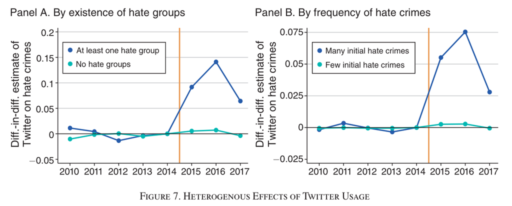

The Twitter effect concentrates where hate groups already exist (Panel A) and where hate crime was already high (Panel B).

## Did Trump actively contribute to the spread?

**Do Trump’s Muslim tweets trigger anti-Muslim hate crimes?**

Figure 8

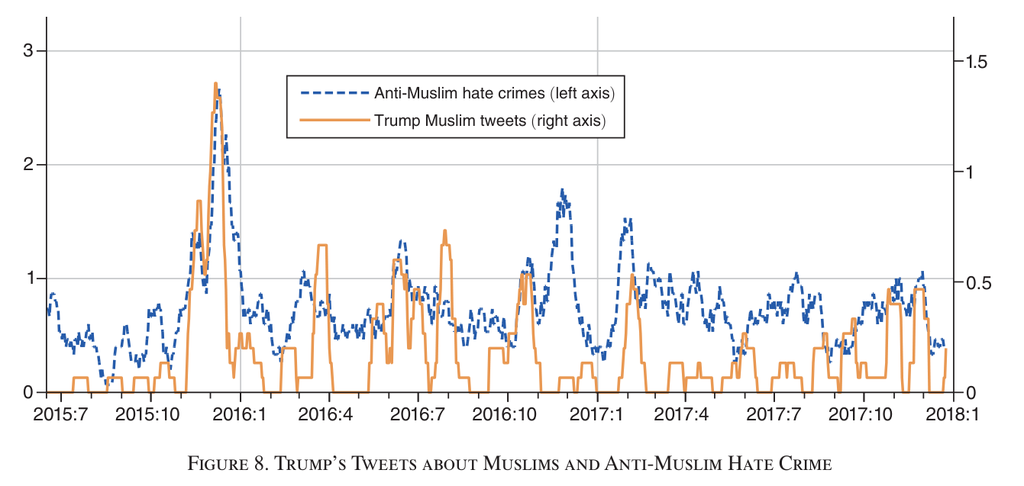

Trump’s Islam-related tweets and anti-Muslim hate crimes move together over the campaign period.

## Identification: golf days

Figure 9

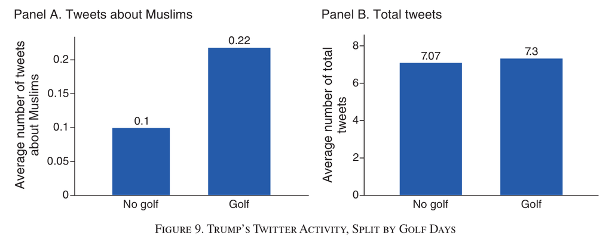

On golf days: more tweets about Muslims (Panel A), but not more tweets overall (Panel B). Instrument for content, not volume.

## Discussion (2 min): golf days

[figure not shown]

**Turn to a neighbor (≈2 min).** Discuss:

1. Why might tweet *content* change on golf days?
2. What alternative explanations would threaten the **exclusion restriction** (golf → hate crime only through Muslim tweets)?

## Discussion: answers

[discussed in class]

## Identification: golf days (estimates)

Figure 10

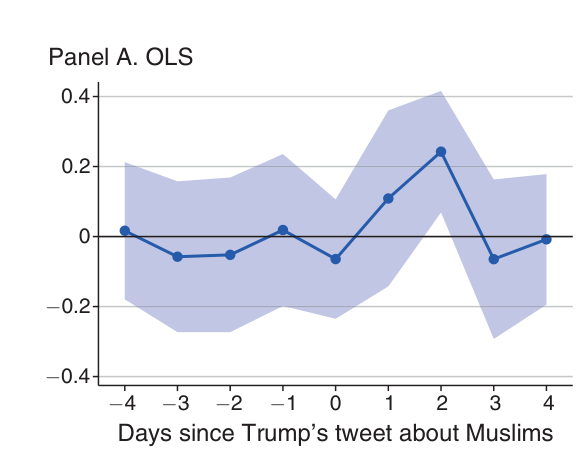

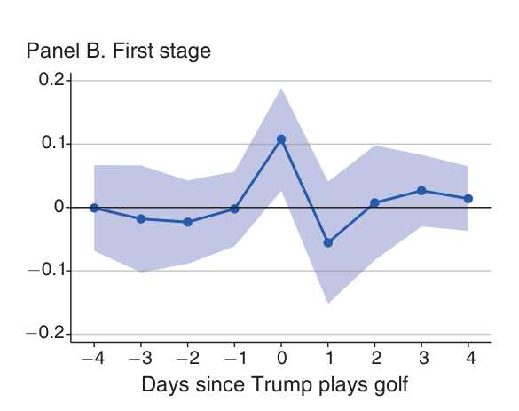

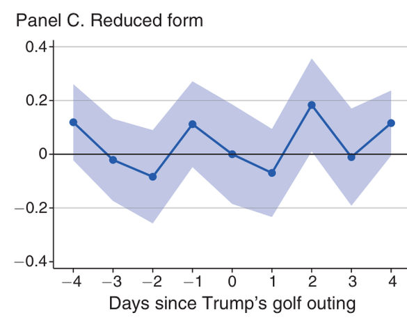

OLS: hate crimes rise after Muslim tweets (Panel A). First stage: golf days spike Muslim tweets (Panel B). Reduced form: golf → hate crimes (Panel C).

## Spillovers to followers

**Do Trump’s tweets spill over among his followers?**

Figure 11

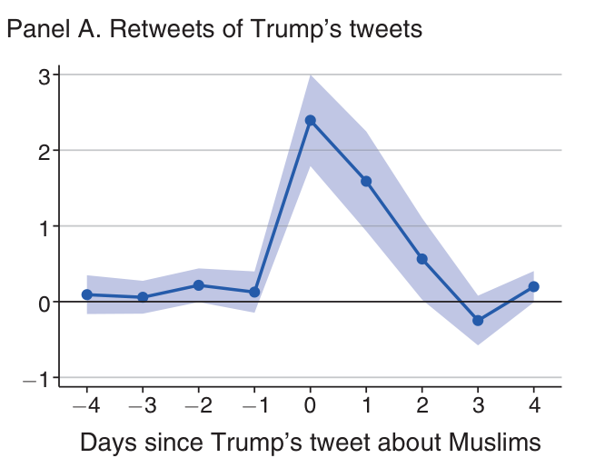

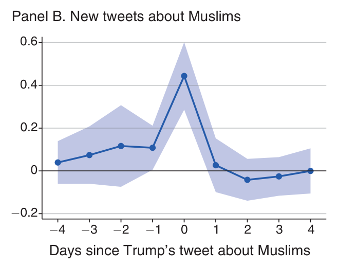

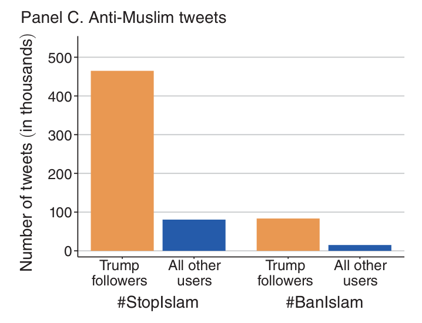

Trump’s Muslim tweets spike retweets (Panel A) and new Muslim tweets (Panel B) the same day; anti-Muslim hashtags concentrate among his followers (Panel C).

## Mechanism: the news cycle

**Do Trump’s tweets also shape the cable news cycle?**

Table 6

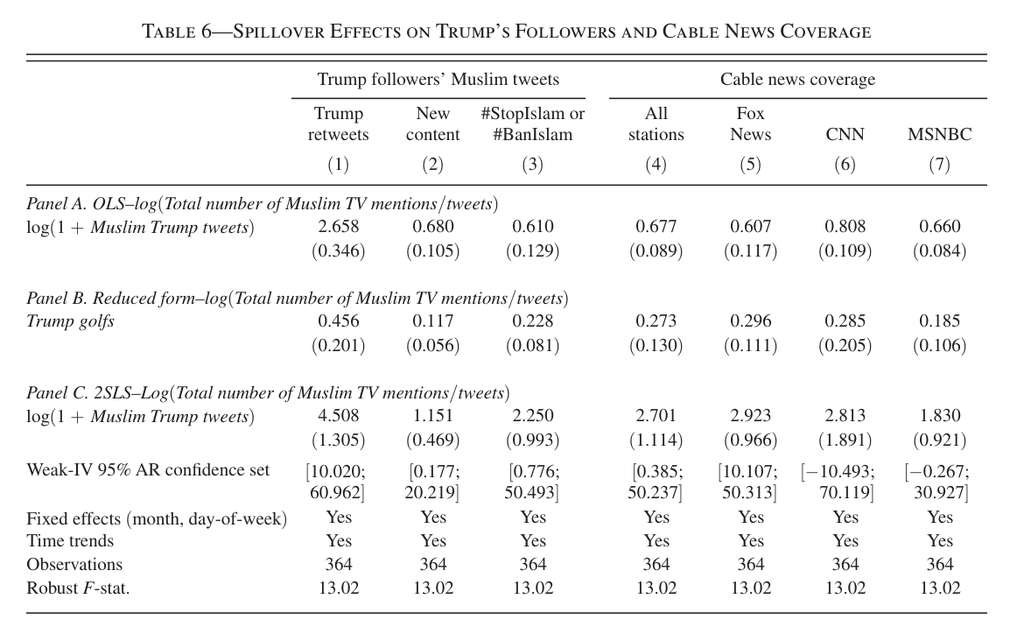

→ Xenophobic rhetoric that travels from Twitter into (often uncritical) broadcast coverage is one suggested trigger for hate crime.

## Critique

Anything else that didn’t convince you?

# Combating online hate speech

## Group Discussion: How to combat online hate?

**Groups of 3–4 (≈5 min).** For each approach, collect **2 points in favor** and **2 drawbacks**. Then: what do you think would be a useful way to deal with hate speech online?

### Approach A: Content moderation

Ban accounts/communities; enforce platform rules (and, where relevant, legal standards).

### Approach B: Counter-speech

Challenge or dilute hate with opposing messages (users, campaigns, or designed interventions).

## How to combat online hate?

[discussed in class]

# Outlook

## Next week: threatening events

**Week 5** (Mon 12/Wed 14 Oct): threatening events and hate crime.

**Required readings**

- Dipoppa, G., Grossman, G., & Zonszein, S. (2023). Locked down, lashing out: COVID-19 effects on Asian hate crimes in Italy. *The Journal of Politics*, 85(2), 389–404.
- Riaz, S., Bischof, D., & Wagner, M. (2024). Out-group threat and xenophobic hate crimes: Evidence of local intergroup conflict dynamics between immigrants and natives. *The Journal of Politics*, 86(4), 1146–1161.
- Álvarez-Benjumea, A., & Winter, F. (2020). The breakdown of antiracist norms: A natural experiment on hate speech after terrorist attacks. *Proceedings of the National Academy of Sciences*, 117(37), 22800–22804.

Weekly comments due **Sunday 11 Oct, 11:59 pm**.

# Questions?

# Goodbye!

See you next week.